# Analysis

Wuwei Zhang

2020/12/16

First, I load data directly from the Data subfolder, and source code directly from from the Code subfolder.

```r
# Load packages.
library(dplyr)
library(tidyr)
library(randomForest)
library(ggplot2)
library(kableExtra)
library(readr)
# Load data.
penguins_data <- load("../Data/my_penguins.rda")
gapminder_data <- load("../Data/my_gapminder.rda")
# Save data.
write_csv(get(penguins_data), "../Data/my_penguins.csv")
write_csv(get(gapminder_data), "../Data/my_gapminder.csv")
# Source code.
source("../Code/my_rf_cv.R")
```

I will use the `my_penguins` data and use `my_rf_cv` function to predict `body_mass_g` using `bill_length_mm`, `bill_depth_mm`, and `flipper_length_mm` with 2-fold cross validation, 5-fold cross validation, and 10-fold cross validation, respectively.

For each k, run the function 30 times to generate 30 CV errors.

```r
k_2 <- rep(NA, 30)
k_5 <- rep(NA, 30)
k_10 <- rep(NA, 30)
# For each k, run the function 30 times to generate 30 CV errors.
for (i in 1:30) {
  k_2[i] <- my_rf_cv(2)
  k_5[i] <- my_rf_cv(5)
  k_10[i] <- my_rf_cv(10)
}
# Store all results in a data frame.
my_data <- data.frame("CV_error" = append(append(k_2, k_5), k_10),
                      "k" = as.factor(rep(c(2, 5, 10), each = 30)))
```

Now, I will make 3 boxplots to display these data in an informative way. Each boxplot is associated with each value of $k$, representing 30 simulations. And save the graph.

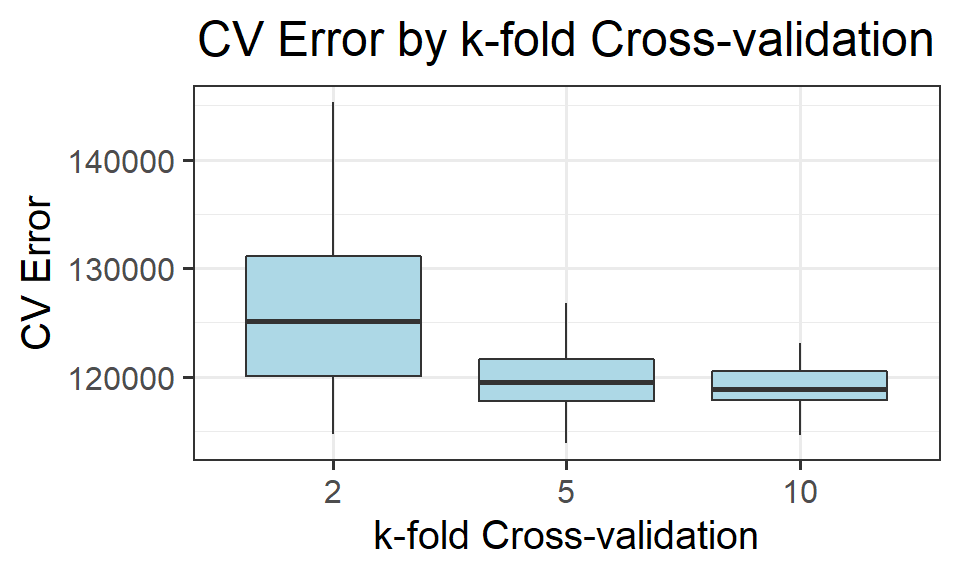

```r
# Make 3 boxplots.
ggplot(data = my_data, aes(x = k, y = CV_error)) +
  geom_boxplot(fill = "lightblue") +
  theme_bw(base_size = 15) +
  labs(title = "CV Error by k-fold Cross-validation",
       x = "k-fold Cross-validation",
       y = "CV Error") +
  theme(plot.title = element_text(hjust = 0.5))
```

```r
# Save the plot.
ggsave("../Output/Figures/boxplots.png")
```

I want to use a table to display the average CV estimate and the standard deviation of the CV estimates across $k$. And save the table.

```r
# Make a table to display the average CV estimate and the standard deviation
# of the CV estimates.
my_table <- cbind(c(mean(k_2), mean(k_5), mean(k_10)),
                  c(sd(k_2), sd(k_5), sd(k_10)))
colnames(my_table) <- c("mean", "standard deviation")
rownames(my_table) <- c("k = 2", "k = 5", "k = 10")
table <- kable_styling(kable(my_table))
table
```

|  | mean | standard deviation |
| --- | --- | --- |
| k = 2 | 126365.3 | 8257.022 |
| k = 5 | 119435.5 | 3065.574 |
| k = 10 | 119133.1 | 2128.635 |

```r
# Save this table.
saveRDS(table, file = "../Output/Results/table.rds")
```

- From the plot, 2-fold cross validation has both largest median and largest IQR of CV error, and 5-fold cross validation and 10-fold cross validation have close values of median and IQR.
- From the table, 2-fold cross validation has both largest mean and largest standard deviation of CV error and 5-fold cross validation and 10-fold cross validation have close values of mean and standard deviation.
- Altogether, 2-fold cross validation generates the largest CV error and has the most variability. 5-fold cross validation and 10-fold cross validation generate close CV errors and have relatively less variability.
- This result seems reasonable. Due to bias-variance tradeoff, using less data to fit the model would increase bias, so with only 2 folds, the test error would increase. Therefore, using `k = 5` or `k = 10` tend to result in an ideal balance in terms of the bias-variance tradeoff.

Finally, Save my simulation results.

```r
# Save simulation results.
result <- as.data.frame(cbind(k_2, k_5, k_10))
write_csv(result, "../Output/Results/simulations.csv")
```